# Part II - Ford GoBike Explanatory Data Analysis

## by (Solomon 'Juwonlo Olorunleke)

## Investigation Overview

> The overall goals of the presentation are to show the following:
> - How long does the average trip takes in terms of minutes and distance.
> - When are the most trips taken in terms of the day and month.
> - Checking whether the trip duration depend on the user type.
> - Using the comparison between user type and duration to check the success.

## Dataset Overview

> This data set includes information about individual rides made in a bike-sharing system covering the greater San Francisco Bay area. Bay Area Bike Share is a company that provides on-demand bike rentals for customers in San Francisco, Redwood City, Palo Alto, Mountain View, and San Jose. The source data (Ford GoBike System Data) is available at : https://s3.amazonaws.com/baywheels-data/index.html.

> My data consist of the information of the bike rides for the first four months of 2019.

> For the wrangling, after downloading the data for each month individually, I combined them together in a compressed zip file and uploaded it into my working directory. I used Zipfile library to read the 4 csv files. For reading the data, I first used glob to find all the CSV files in my directory before using a for loop to read all 4 files at a go. I combined the datasets into into one and named it Ford2019.csv.

> I assessed the data programmatically, by looking into its head, tail, unique values, and value counts. I used info, describe, isnull and duplicated option to look deeper into the data

> For the cleaning, I dropped the null values, dropped an irrevelant column, created more features that would aid my analysis and chnaged the features to the appropriate datatypes.

## How long does the average trip takes in terms of minutes and distance?

> The average trip takes about 3 - 11 minutes.

> The average distance travelled by riders takes about 2 kilometres.

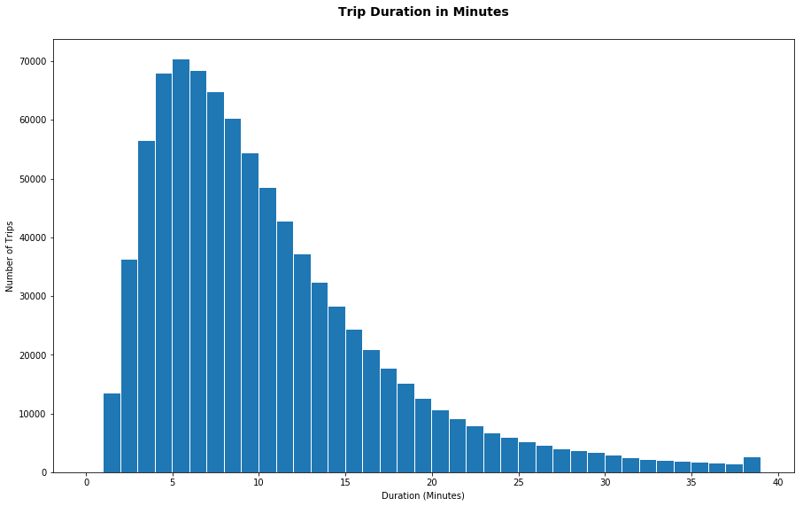

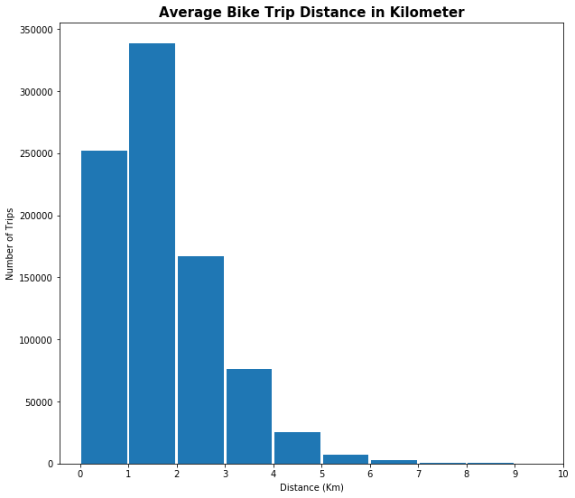

## When are the most trips taken in terms of the day and month?

> Thursday is the most popular day to use the Ford Go Bike sharing system in the Bay Area. It records over 150,000 rides.

> With over 250,000 trips, March is the most popular month. It records the highest number of usage for the Ford Go Bike sharing system in the Bay Area

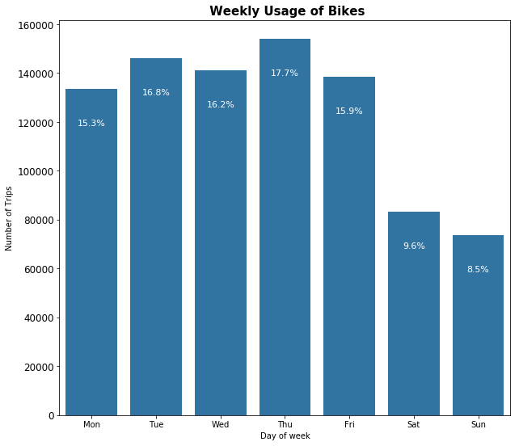

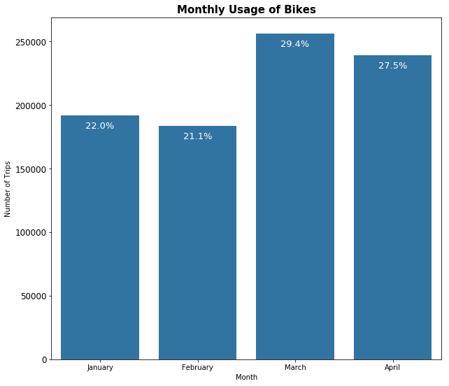

## Does the trip duration depend on the user type?

> When viewed by month and without setting limits, the plot shows that some customers had similar trip durations with subscribers for February to April. The trip duration for customers in January are slightly higher than subscribers'.

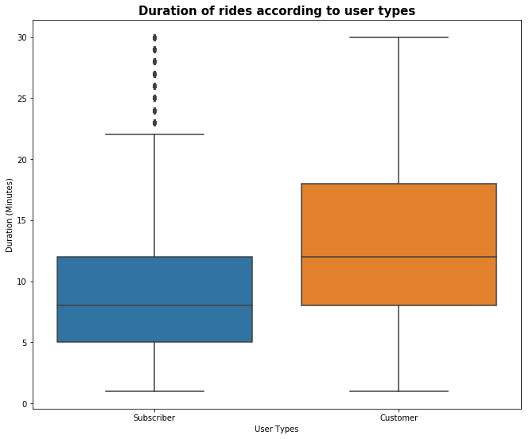

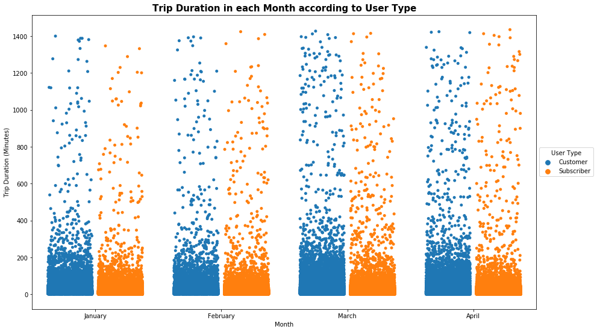

## Is the relationship between user type and trip a duration a success?

NO!